# Malle ERW: Bayesian SoilR Treatment Comparisons

Primary treatment-versus-Control forest plots

## Overview

Treatment effects were evaluated through posterior contrasts between each amendment treatment and the Control, comprising Lime, Hühnerberg (50 t ha(^{-1})), Eifelgold (50 t ha(^{-1})), and Bolsdorfer (50 t ha(^{-1})). For each contrast, 10,000 differences were generated by independently sampling from the corresponding treatment and Control posterior distributions. The median posterior difference and associated 95% credible interval (CrI; 2.5th and 97.5th percentiles) were calculated, together with the posterior probabilities that the treatment value was greater or lower than the Control value. A treatment effect was considered to be supported by the posterior distribution when its 95% CrI did not include zero. Results are presented as forest plots of treatment–Control differences. All comparisons were based on the existing treatment-level SoilR model outputs; consequently, these contrasts quantify differences between treatment-level posterior distributions and do not represent a hierarchical model of plot-level variation.

## Load saved Bayesian results

This document loads the completed RDS object generated by `Malle_SoilR_Bayesian_Treatment_Comparisons.R`. It does not refit the SoilR models, recalculate posterior contrasts, or load previously exported plot images. All figures below are reconstructed directly from the saved posterior comparison results.

## Primary treatment-versus-Control forest plots

Each point represents the median posterior treatment-minus-Control difference. Horizontal lines show the 95% credible intervals.

**Each response has an independent horizontal axis scale**, allowing responses with substantially different magnitudes (for example, fPOM and MAOM mean ages) to be viewed at an appropriate scale.

Differences are displayed on the original, unstandardised parameter scales:

- Decomposition rates: yr⁻¹
- Transfer coefficients: dimensionless
- Carbon-pool ages: years
- System transit time: years

Differences greater than zero indicate higher values in the amendment treatment than in the Control; differences below zero indicate lower values. Credible intervals that do not cross zero indicate contrasts for which the posterior distribution supports a difference from the Control.

### Decomposition rates

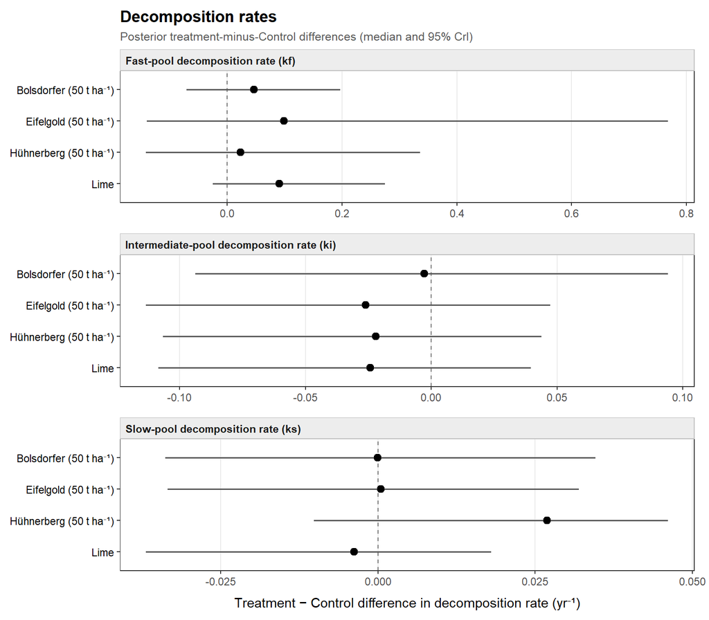

### Transfer coefficients

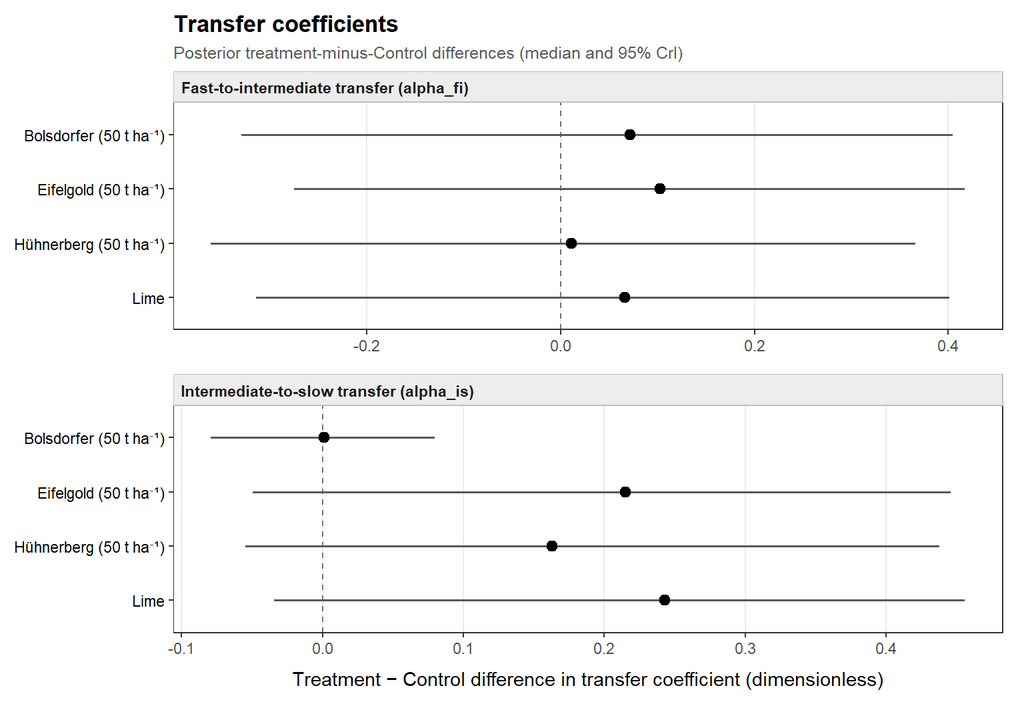

### Mean carbon-pool ages

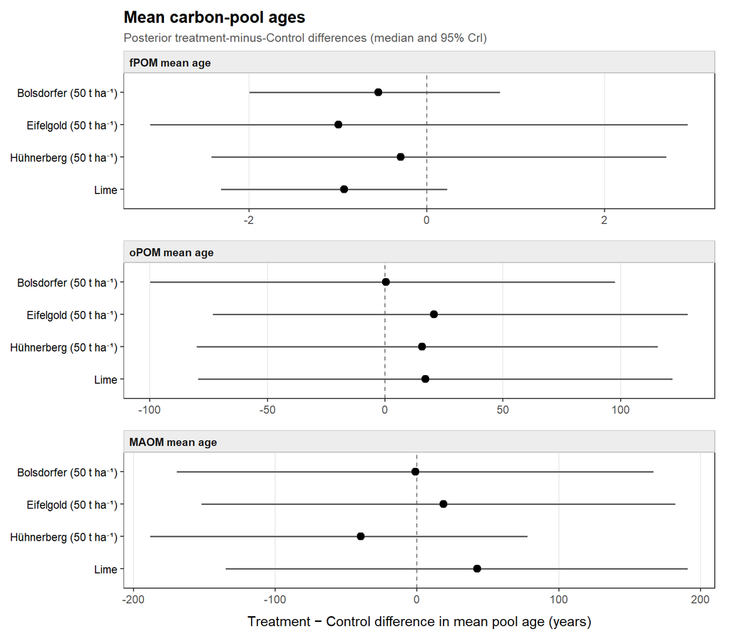

### Whole-system transit time

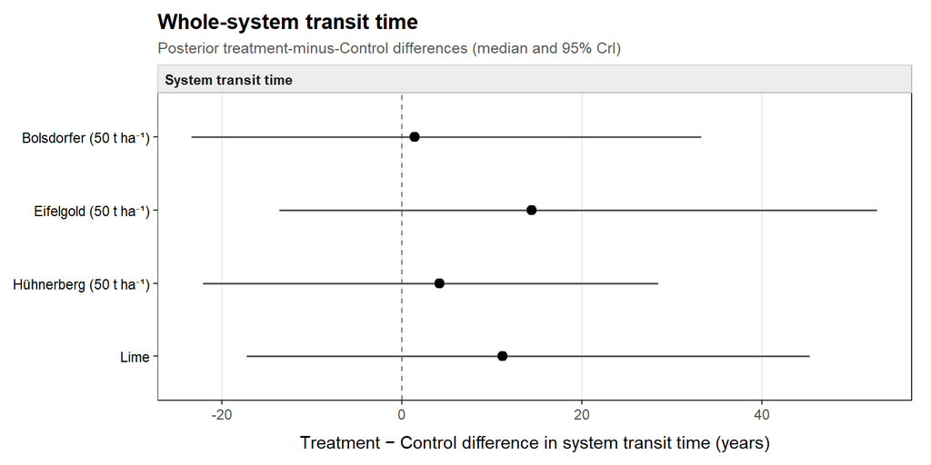